# MScA Linear and Non-Linear Models (31010) Week 6: Workshop Contingency Tables

© Yuri Balasanov, iLykei 2015

```r
suppressWarnings(library(faraway))
```

### Example with `babyfood` data

Select only data for boys to create a 1-way contingency table.

```r
data( babyfood)
Boys.only.table<-as.data.frame(babyfood[1:3,1:2])
rownames(Boys.only.table)<-as.character(babyfood[1:3,4])
Boys.only.table
```

```
##        disease nondisease
## Bottle      77        381
## Suppl       19        128
## Breast      47        447
```

#### 1. Simple Method

Create contingency table with total counts.

```r
Contingency.Table<-t(Boys.only.table)
Full.Contingency.Table<-cbind(Contingency.Table,apply(Contingency.Table,1,sum))
Full.Contingency.Table<-rbind(Full.Contingency.Table,apply(Full.Contingency.Table,2,sum))
Full.Contingency.Table
```

```
##            Bottle Suppl Breast
## disease        77    19     47  143
## nondisease    381   128    447  956
##               458   147    494 1099
```

Calculate mean values for each cell.

```r
(Contingency.Table.Means<-t(outer(Full.Contingency.Table[3,1:3],Full.Contingency.Table[1:2,4]))/
  Full.Contingency.Table[3,4])
```

```
##               Bottle     Suppl    Breast
## disease     59.59418  19.12739  64.27843
## nondisease 398.40582 127.87261 429.72157
```

Check how the mean values are calculated.

```r
sum(Full.Contingency.Table[1,1:3])*sum(Full.Contingency.Table[1:2,1])/Full.Contingency.Table[3,4]
```

```
## [1] 59.59418
```

Let $N_{B_1},N_{A_1}$ be sums of the first column and first row, correspondingly.  
Let also $N$ be the total number of observations in contingency table.  
Then $\mu_{1,1}= N_{A_1} \frac{N_{B_1}}{N}$, i.e. the total number of cases corresponding to $A_1$ (number of Bernulli trials) multiplied by the sample probablility of $B_1$ (probability of success). So, mean is calculated as number of Bernulli trials, times probability of success.

To test the null $H_0$ : “There is no difference between factors” calculate the Chi-Square statistic and its p-value.

```r
Chi.Sq.Statistic<-sum((Contingency.Table-Contingency.Table.Means)^2/Contingency.Table.Means)
Chi.Sq.Statistic
```

```
## [1] 11.18446
```

```r
1-pchisq(Chi.Sq.Statistic,2)
```

```
## [1] 0.003726701
```

The p-value shows that $H_0$ is rejected. Feeding method has effect on proneness to respiratory disease.  
For an indicator of which feeding method is more important look at deviations from the mean values:

```r
Contingency.Table-Contingency.Table.Means
```

```
##               Bottle      Suppl    Breast
## disease     17.40582 -0.1273885 -17.27843
## nondisease -17.40582  0.1273885  17.27843
```

#### 2. Binomial Regression

Fit null binomial regression model

```r
(Binomial.Model.Data<-as.data.frame(cbind(Boys.only.table,food=rownames(Boys.only.table))))
```

```
##        disease nondisease   food
## Bottle      77        381 Bottle
## Suppl       19        128  Suppl
## Breast      47        447 Breast
```

```r
Boys.binomial.model.null<-glm(as.matrix(Binomial.Model.Data[,1:2])~1,family=binomial,data=Binomial.Model.Data)
summary(Boys.binomial.model.null)
```

```
##
## Call:
## glm(formula = as.matrix(Binomial.Model.Data[, 1:2]) ~ 1, family = binomial,
##     data = Binomial.Model.Data)
##
## Deviance Residuals:
##   Bottle     Suppl    Breast
##  2.32857  -0.03126  -2.41107
##
## Coefficients:
##             Estimate Std. Error z value Pr(>|z|)
## (Intercept) -1.89991    0.08966  -21.19   <2e-16 ***
## ---
## Signif. codes:  0 '***' 0.001 '**' 0.01 '*' 0.05 '.' 0.1 ' ' 1
##
## (Dispersion parameter for binomial family taken to be 1)
##
##     Null deviance: 11.236  on 2  degrees of freedom
## Residual deviance: 11.236  on 2  degrees of freedom
## AIC: 29.481
##
## Number of Fisher Scoring iterations: 4
```

What data the model fits when we give it contingency table?

```r
Boys.binomial.model.null$y
```

```
##    Bottle     Suppl    Breast
## 0.1681223 0.1292517 0.0951417
```

```r
t(as.matrix(Binomial.Model.Data[,1])/(apply(as.matrix(Binomial.Model.Data[,1:2]),1,sum)))
```

```
##           [,1]      [,2]      [,3]
## [1,] 0.1681223 0.1292517 0.0951417
```

The output is recalculated as probability of disease.

**Note on residuals**. Residuals in general case are contributions of each observation to the goodness of fit statistic.  
Pearson residuals are related to Pearson goodness of fit statistic $\chi^2=\sum_{j=1}^k r_j^2$, where

$$r_j^2= \frac{(x_j - n \hat{p}_j)^2}{n \hat{p}_j} = \frac{(x_j -\mu_j)^2}{\mu_j}$$
is the contribution of observation $x_j$ to the $\chi^2$ statistic.

Smilarly, deviance residuals $r_d$ are such residuals that

$$\sum r_d^2 = D,$$
where $D$ is the deviance.
For example, for Poisson model
$$r_d = sign(y-\hat{\mu}) \sqrt{2 (y\frac{ \ln y}{\hat{\mu}}-y+\hat{\mu})}$$

```r
residuals(Boys.binomial.model.null)
```

```
##     Bottle      Suppl     Breast
##  2.3285699 -0.0312596 -2.4110746
```

```r
residuals(Boys.binomial.model.null,type="pearson")
```

```
##      Bottle       Suppl      Breast
##  2.41747818 -0.03123003 -2.31068984
```

```r
residuals(Boys.binomial.model.null,type="deviance")
```

```
##     Bottle      Suppl     Breast
##  2.3285699 -0.0312596 -2.4110746
```

Residuals returned by default are deviance residuals.

The model does not show a good fit: the residual deviance is 11.236 on 2 degrees of freedom.

Fit additive model.

```r
Boys.binomial.model.additive<-glm(as.matrix(Binomial.Model.Data[,1:2])~food,family=binomial,data=Binomial.Model.Data)
summary(Boys.binomial.model.additive)
```

```
##
## Call:
## glm(formula = as.matrix(Binomial.Model.Data[, 1:2]) ~ food, family = binomial,
##     data = Binomial.Model.Data)
##
## Deviance Residuals:
## [1]  0  0  0
##
## Coefficients:
##             Estimate Std. Error z value Pr(>|z|)
## (Intercept)  -1.5990     0.1249 -12.797  < 2e-16 ***
## foodBreast   -0.6534     0.1978  -3.303 0.000955 ***
## foodSuppl    -0.3086     0.2758  -1.119 0.263145
## ---
## Signif. codes:  0 '***' 0.001 '**' 0.01 '*' 0.05 '.' 0.1 ' ' 1
##
## (Dispersion parameter for binomial family taken to be 1)
##
##     Null deviance:  1.1236e+01  on 2  degrees of freedom
## Residual deviance: -9.9476e-14  on 0  degrees of freedom
## AIC: 22.244
##
## Number of Fisher Scoring iterations: 3
```

```r
Boys.binomial.model.additive<-glm(as.matrix(Binomial.Model.Data[-2,1:2])~food,family=binomial,data=Binomial.Model.Data[-2,])
summary(Boys.binomial.model.additive)
```

```
##
## Call:
## glm(formula = as.matrix(Binomial.Model.Data[-2, 1:2]) ~ food,
##     family = binomial, data = Binomial.Model.Data[-2, ])
##
## Deviance Residuals:
## [1]  0  0
##
## Coefficients:
##             Estimate Std. Error z value Pr(>|z|)
## (Intercept)  -1.5990     0.1249 -12.797  < 2e-16 ***
## foodBreast   -0.6534     0.1978  -3.303 0.000955 ***
## ---
## Signif. codes:  0 '***' 0.001 '**' 0.01 '*' 0.05 '.' 0.1 ' ' 1
##
## (Dispersion parameter for binomial family taken to be 1)
##
##     Null deviance: 1.1235e+01  on 1  degrees of freedom
## Residual deviance: 4.1744e-14  on 0  degrees of freedom
## AIC: 15.591
##
## Number of Fisher Scoring iterations: 3
```

We see that both models with 2 and 3 parameters are saturated: residual deviance and degrees of freedom are zeros.

Note that the model for log-odds of disease is

$$\ln(Odds) = \beta_0 + \beta_1 I_{foodBreast}$$
or
$$Odds = \exp{\beta_0} \exp(\beta_1 I_{foodBreast}) )$$

Each exponential multiplier shows how much the odds increase/drop relative to the first group.

Calculate each of them.

```r
exp(Boys.binomial.model.additive$coefficients)
```

```
## (Intercept)  foodBreast
##   0.2020997   0.5202650
```

**Conclusions:**  
**1. Binomial model with 2 and 3 parameters is saturated**  
**2. Nevertheless, the estimated coefficients reproduce conclusion from Lecture 4 that breast feeding reduces the odds of diseas by a factor of 51-52%.**  
**3. Null hypothesis confirms importance of food type.**

#### 2. Poisson Model

Create the data for Poisson model

```r
Counts<-c(77,19,47,381,128,447)
diseas<-c("yes","yes","yes","no","no","no")
food<-c("Bottle","Suppl","Breast","Bottle","Suppl","Breast")
(poi.data<-data.frame(Counts,diseas,food))
```

```
##   Counts diseas   food
## 1     77    yes Bottle
## 2     19    yes  Suppl
## 3     47    yes Breast
## 4    381     no Bottle
## 5    128     no  Suppl
## 6    447     no Breast
```

Fit additive Poisson model to the data in `poi.data`

```r
Poisson.Model<-glm(Counts~diseas+food,family=poisson,data=poi.data)
summary(Poisson.Model)
```

```
##
## Call:
## glm(formula = Counts ~ diseas + food, family = poisson, data = poi.data)
##
## Deviance Residuals:
##        1         2         3         4         5         6
##  2.15650  -0.02916  -2.26444  -0.87850   0.01126   0.82802
##
## Coefficients:
##             Estimate Std. Error z value Pr(>|z|)
## (Intercept)  5.98747    0.04816 124.321   <2e-16 ***
## diseasyes   -1.89991    0.08966 -21.190   <2e-16 ***
## foodBreast   0.07567    0.06487   1.166    0.243
## foodSuppl   -1.13644    0.09480 -11.988   <2e-16 ***
## ---
## Signif. codes:  0 '***' 0.001 '**' 0.01 '*' 0.05 '.' 0.1 ' ' 1
##
## (Dispersion parameter for poisson family taken to be 1)
##
##     Null deviance: 916.517  on 5  degrees of freedom
## Residual deviance:  11.236  on 2  degrees of freedom
## AIC: 58.316
##
## Number of Fisher Scoring iterations: 4
```

The null model which would mean that all types of events come with the same intensity, does not give a good fit.

Now exponent of the coefficients tells how much the intensity changes.

```r
exp(Poisson.Model$coeff)
```

```
## (Intercept)   diseasyes  foodBreast   foodSuppl
## 398.4058235   0.1495816   1.0786026   0.3209607
```

Intercept corresponds to healthy bottle fed boys.  
Diseased boys arrive with intensity of 15% of that and healthy breast fed boys arrive with intensity of 108% of that.

### Data for the example on page 69

The data shows experiment with semiconductors wafers.  
The question is whether the quality is affected by particles found on wafers.

```r
y<-c(320,14,80,36)
particle<-gl(2,1,4,labels=c("no","yes"))
quality<-gl(2,2,labels=c("good","bad"))
wafer<-data.frame(y,particle,quality)
wafer
```

```
##     y particle quality
## 1 320       no    good
## 2  14      yes    good
## 3  80       no     bad
## 4  36      yes     bad
```

### Poisson model

Assume that we observe the manufacturing process for some time and see the numbers in the table.

```r
ov<-xtabs(y~quality+particle,wafer)
ov
```

```
##        particle
## quality  no yes
##    good 320  14
##    bad   80  36
```

```r
mod1<-glm(y~particle+quality,wafer,family=poisson)
mod1
```

```
##
## Call:  glm(formula = y ~ particle + quality, family = poisson, data = wafer)
##
## Coefficients:
## (Intercept)  particleyes   qualitybad
##       5.693       -2.079       -1.058
##
## Degrees of Freedom: 3 Total (i.e. Null);  1 Residual
## Null Deviance:       474.1
## Residual Deviance: 54.03     AIC: 83.77
```

```r
summary(mod1)
```

```
##
## Call:
## glm(formula = y ~ particle + quality, family = poisson, data = wafer)
##
## Deviance Residuals:
##      1       2       3       4
##  1.324  -4.350  -2.370   5.266
##
## Coefficients:
##             Estimate Std. Error z value Pr(>|z|)
## (Intercept)   5.6934     0.0572  99.535   <2e-16 ***
## particleyes  -2.0794     0.1500 -13.863   <2e-16 ***
## qualitybad   -1.0575     0.1078  -9.813   <2e-16 ***
## ---
## Signif. codes:  0 '***' 0.001 '**' 0.01 '*' 0.05 '.' 0.1 ' ' 1
##
## (Dispersion parameter for poisson family taken to be 1)
##
##     Null deviance: 474.10  on 3  degrees of freedom
## Residual deviance:  54.03  on 1  degrees of freedom
## AIC: 83.774
##
## Number of Fisher Scoring iterations: 5
```

```r
mod1.1<-summary(glm(y~quality,wafer,family=poisson))
mod1.2<-summary(glm(y~particle,wafer,family=poisson))
drop1(mod1,test="Chi")
```

```
## Single term deletions
##
## Model:
## y ~ particle + quality
##          Df Deviance    AIC    LRT  Pr(>Chi)
## <none>         54.03  83.77
## particle  1   363.91 391.66 309.88 < 2.2e-16 ***
## quality   1   164.22 191.96 110.19 < 2.2e-16 ***
## ---
## Signif. codes:  0 '***' 0.001 '**' 0.01 '*' 0.05 '.' 0.1 ' ' 1
```

```r
mod1.1
```

```
##
## Call:
## glm(formula = y ~ quality, family = poisson, data = wafer)
##
## Deviance Residuals:
##       1        2        3        4
##  10.498  -15.382    2.730   -3.108
##
## Coefficients:
##             Estimate Std. Error z value Pr(>|z|)
## (Intercept)  5.11799    0.05472  93.536   <2e-16 ***
## qualitybad  -1.05755    0.10777  -9.813   <2e-16 ***
## ---
## Signif. codes:  0 '***' 0.001 '**' 0.01 '*' 0.05 '.' 0.1 ' ' 1
##
## (Dispersion parameter for poisson family taken to be 1)
##
##     Null deviance: 474.10  on 3  degrees of freedom
## Residual deviance: 363.91  on 2  degrees of freedom
## AIC: 391.66
##
## Number of Fisher Scoring iterations: 5
```

```r
mod1.2
```

```
##
## Call:
## glm(formula = y ~ particle, family = poisson, data = wafer)
##
## Deviance Residuals:
##      1       2       3       4
##  7.798  -2.401  -9.664   2.063
##
## Coefficients:
##             Estimate Std. Error z value Pr(>|z|)
## (Intercept)    5.298      0.050  105.97   <2e-16 ***
## particleyes   -2.079      0.150  -13.86   <2e-16 ***
## ---
## Signif. codes:  0 '***' 0.001 '**' 0.01 '*' 0.05 '.' 0.1 ' ' 1
##
## (Dispersion parameter for poisson family taken to be 1)
##
##     Null deviance: 474.10  on 3  degrees of freedom
## Residual deviance: 164.22  on 2  degrees of freedom
## AIC: 191.96
##
## Number of Fisher Scoring iterations: 5
```

Read discussion at the bottom of page 71 - top of page 72.

**Why do we conclude that with deviance of 54.03 and degrees of freedom 1 the model does not fit?**

### Multinomial model

Note the relationship between Poisson distribution and multinomial distribution on page 73.

Let $Y_1,\ldots,Y_k$ be independent Poisson random variables with means $\lambda_1,\ldots,\lambda_k$.  
Then the joint distribution of $Y_1,\ldots,Y_k|\sum_{i=1}^k Y_i = n$ is multinomial with probabilities

$$p_j=\frac{\lambda_j}{\sum_{i=1}^k \lambda_i}.$$

So, there is no difference between the Poisson model and multinomial model.  
But Poisson is a little easier to deal with.

### Binomial model

Note how we formulate the binomial model problem: create 2 groups and check if they have the same probability of success.

```r
(m<-matrix(y,nrow=2))
```

```
##      [,1] [,2]
## [1,]  320   80
## [2,]   14   36
```

```r
modb<-glm(m~1,family=binomial)
summary(modb)
```

```
##
## Call:
## glm(formula = m ~ 1, family = binomial)
##
## Deviance Residuals:
##      1       2
##  2.715  -6.831
##
## Coefficients:
##             Estimate Std. Error z value Pr(>|z|)
## (Intercept)   1.0576     0.1078   9.813   <2e-16 ***
## ---
## Signif. codes:  0 '***' 0.001 '**' 0.01 '*' 0.05 '.' 0.1 ' ' 1
##
## (Dispersion parameter for binomial family taken to be 1)
##
##     Null deviance: 54.03  on 1  degrees of freedom
## Residual deviance: 54.03  on 1  degrees of freedom
## AIC: 66.191
##
## Number of Fisher Scoring iterations: 3
```

```r
deviance(modb)
```

```
## [1] 54.03045
```

Null model means that predictor (particles) is not involved. If the model fits well predictor is irrelevant.

**What exactly we fit by `modb`?**

Check the fields of the object `modb`.

```r
names(modb)
```

```
##  [1] "coefficients"      "residuals"         "fitted.values"
##  [4] "effects"           "R"                 "rank"
##  [7] "qr"                "family"            "linear.predictors"
## [10] "deviance"          "aic"               "null.deviance"
## [13] "iter"              "weights"           "prior.weights"
## [16] "df.residual"       "df.null"           "y"
## [19] "converged"         "boundary"          "model"
## [22] "call"              "formula"           "terms"
## [25] "data"              "offset"            "control"
## [28] "method"            "contrasts"         "xlevels"
```

```r
modb$y
```

```
##    1    2
## 0.80 0.28
```

**How was the output `modb$y` created from `m` or `ov`, both of which are grouped versions of `wafer`?**

```r
wafer
```

```
##     y particle quality
## 1 320       no    good
## 2  14      yes    good
## 3  80       no     bad
## 4  36      yes     bad
```

```r
m
```

```
##      [,1] [,2]
## [1,]  320   80
## [2,]   14   36
```

```r
ov
```

```
##        particle
## quality  no yes
##    good 320  14
##    bad   80  36
```

**What link is used in `modb`?**  
**Explain the values of `modb$linear.predictors`, `fitted.values`.**

```r
modb$y
```

```
##    1    2
## 0.80 0.28
```

```r
modb$linear.predictors
```

```
##        1        2
## 1.057551 1.057551
```

```r
modb$coeff
```

```
## (Intercept)
##    1.057551
```

```r
modb$fitted.values
```

```
##         1         2
## 0.7422222 0.7422222
```

**What does fitting of `glm()` tell us about the effect of `particle`?**

### Visualization of tables

```r
data(haireye)
haireye
```

```
##      y   eye  hair
## 1    5 green BLACK
## 2   29 green BROWN
## 3   14 green   RED
## 4   16 green BLOND
## 5   15 hazel BLACK
## 6   54 hazel BROWN
## 7   14 hazel   RED
## 8   10 hazel BLOND
## 9   20  blue BLACK
## 10  84  blue BROWN
## 11  17  blue   RED
## 12  94  blue BLOND
## 13  68 brown BLACK
## 14 119 brown BROWN
## 15  26 brown   RED
## 16   7 brown BLOND
```

```r
(ct<-xtabs(y~hair+eye,haireye))
```

```
##        eye
## hair    green hazel blue brown
##   BLACK     5    15   20    68
##   BROWN    29    54   84   119
##   RED      14    14   17    26
##   BLOND    16    10   94     7
```

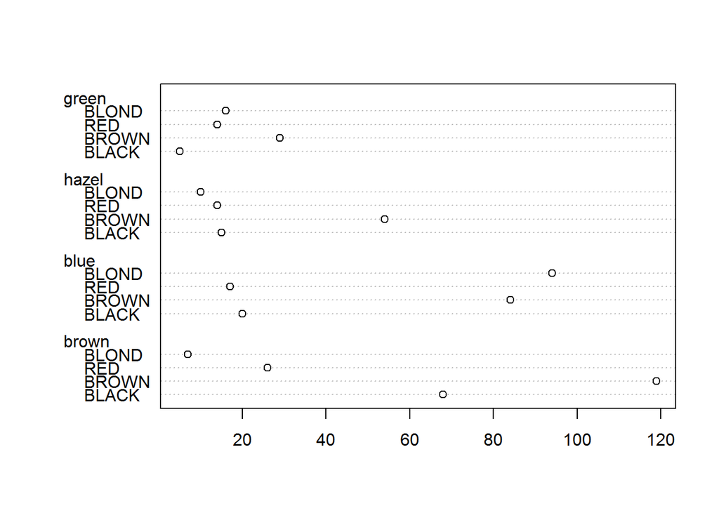

```r
dotchart(ct)
```

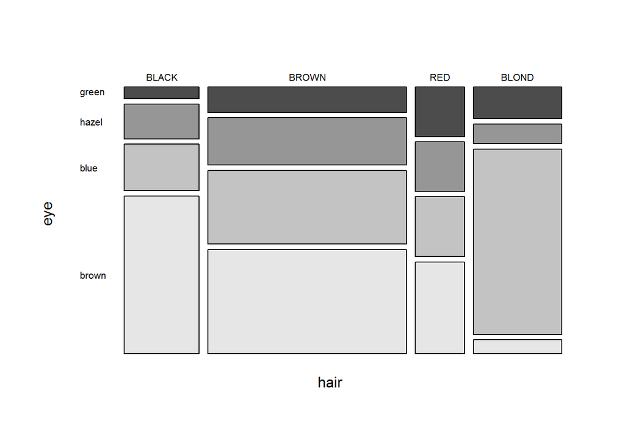

```r
mosaicplot(ct,color=TRUE,main=NULL,las=1)
```

For recommendations on how to interpret mosaic plots check sources available on the web, for example [this](http://alumni.media.mit.edu/~tpminka/courses/36-350.2001/lectures/day12/).

### Larger Contingency Tables

```r
library(faraway)
data(haireye)
haireye
```

```
##      y   eye  hair
## 1    5 green BLACK
## 2   29 green BROWN
## 3   14 green   RED
## 4   16 green BLOND
## 5   15 hazel BLACK
## 6   54 hazel BROWN
## 7   14 hazel   RED
## 8   10 hazel BLOND
## 9   20  blue BLACK
## 10  84  blue BROWN
## 11  17  blue   RED
## 12  94  blue BLOND
## 13  68 brown BLACK
## 14 119 brown BROWN
## 15  26 brown   RED
## 16   7 brown BLOND
```

```r
(ct<-xtabs(y~hair+eye,haireye))
```

```
##        eye
## hair    green hazel blue brown
##   BLACK     5    15   20    68
##   BROWN    29    54   84   119
##   RED      14    14   17    26
##   BLOND    16    10   94     7
```

```r
summary(ct)
```

```
## Call: xtabs(formula = y ~ hair + eye, data = haireye)
## Number of cases in table: 592
## Number of factors: 2
## Test for independence of all factors:
##  Chisq = 138.29, df = 9, p-value = 2.325e-25
```

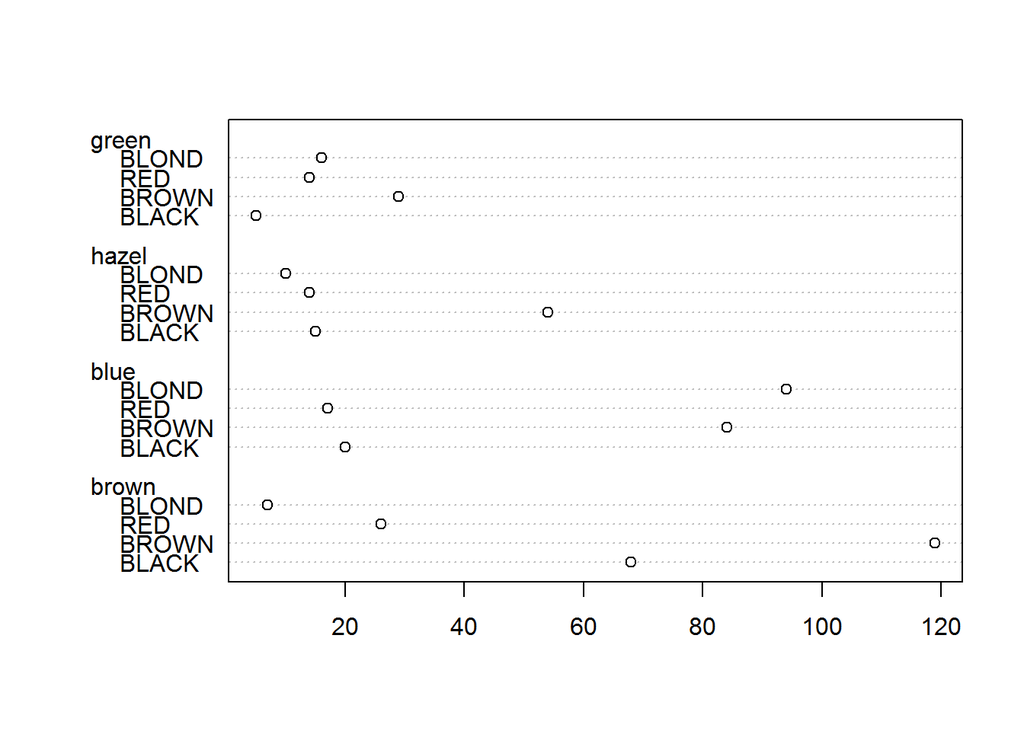

```r
dotchart(ct)
```

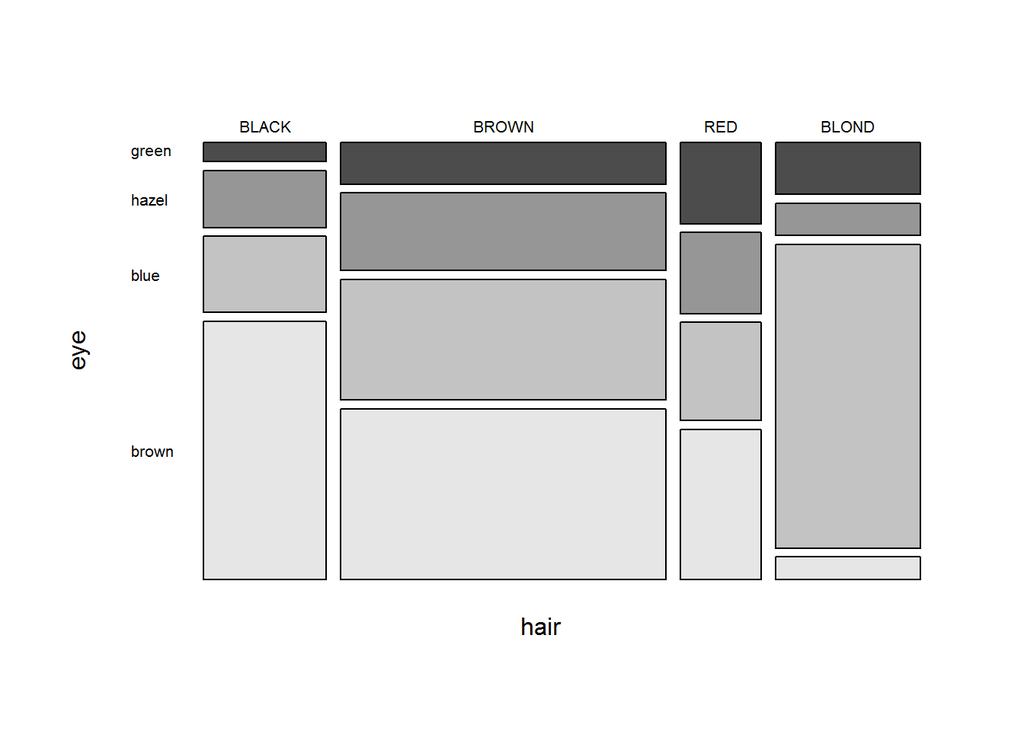

```r
mosaicplot(ct,color=TRUE,main=NULL,las=1)
```

For recommendations on how to interpret mosaic plots there are number of sources, for example [this](http://alumni.media.mit.edu/~tpminka/courses/36-350.2001/lectures/day12/).

Fit Poisson model

```r
modc<-glm(y~hair+eye,family=poisson,haireye)
summary(modc)
```

```
##
## Call:
## glm(formula = y ~ hair + eye, family = poisson, data = haireye)
##
## Deviance Residuals:
##    Min      1Q  Median      3Q     Max
## -7.326  -2.065  -0.212   1.235   6.172
##
## Coefficients:
##             Estimate Std. Error z value Pr(>|z|)
## (Intercept)   2.4575     0.1523  16.136  < 2e-16 ***
## hairBROWN     0.9739     0.1129   8.623  < 2e-16 ***
## hairRED      -0.4195     0.1528  -2.745  0.00604 **
## hairBLOND     0.1621     0.1309   1.238  0.21569
## eyehazel      0.3737     0.1624   2.301  0.02139 *
## eyeblue       1.2118     0.1424   8.510  < 2e-16 ***
## eyebrown      1.2347     0.1420   8.694  < 2e-16 ***
## ---
## Signif. codes:  0 '***' 0.001 '**' 0.01 '*' 0.05 '.' 0.1 ' ' 1
##
## (Dispersion parameter for poisson family taken to be 1)
##
##     Null deviance: 453.31  on 15  degrees of freedom
## Residual deviance: 146.44  on  9  degrees of freedom
## AIC: 241.04
##
## Number of Fisher Scoring iterations: 5
```

The Poisson model fit is very bad.  
One of the reasons could be overdispersion.  
However, it could be just wrong distributional assumption.  
Check if negative binomial distribution can do a better job fitting the data.

```r
library(MASS)
modc.nb<-glm.nb(y~hair+eye,haireye)
summary(modc.nb)
```

```
##
## Call:
## glm.nb(formula = y ~ hair + eye, data = haireye, init.theta = 3.866552908,
##     link = log)
##
## Deviance Residuals:
##      Min        1Q    Median        3Q       Max
## -2.56592  -0.94035  -0.09116   0.32154   1.60253
##
## Coefficients:
##             Estimate Std. Error z value Pr(>|z|)
## (Intercept)   2.4027     0.3774   6.366 1.94e-10 ***
## hairBROWN     1.0904     0.3829   2.848  0.00440 **
## hairRED      -0.1929     0.3969  -0.486  0.62701
## hairBLOND     0.2098     0.3906   0.537  0.59112
## eyehazel      0.2789     0.4020   0.694  0.48784
## eyeblue       1.1915     0.3917   3.042  0.00235 **
## eyebrown      1.1876     0.3917   3.032  0.00243 **
## ---
## Signif. codes:  0 '***' 0.001 '**' 0.01 '*' 0.05 '.' 0.1 ' ' 1
##
## (Dispersion parameter for Negative Binomial(3.8666) family taken to be 1)
##
##     Null deviance: 45.546  on 15  degrees of freedom
## Residual deviance: 16.305  on  9  degrees of freedom
## AIC: 146.03
##
## Number of Fisher Scoring iterations: 1
##
##
##               Theta:  3.87
##           Std. Err.:  1.53
##
##  2 x log-likelihood:  -130.029
```

```r
c(mean(haireye$y),var(haireye$y))
```

```
## [1]   37.0 1262.8
```

Indeed the correct distribution for the data was negative binomial.  
We see that the estimated dispersion parameter $\theta$ is 3.87 (with standard deviation 1.53) which is low.  
Sample mean and sample variance show very significant overdispersion.

Overdispersion of negative binomial over Poisson distribution is the result of gamma-distributed intensity of Poisson process.  
This is an indication of different intensities for different groups.

Remember that intercept corresponds to black hair-green eyes combination.  
Interpret the coefficients:

```r
exp(modc.nb$coeff)
```

```
## (Intercept)   hairBROWN     hairRED   hairBLOND    eyehazel     eyeblue
##  11.0533443   2.9755468   0.8245938   1.2334752   1.3216615   3.2920184
##    eyebrown
##   3.2791246
```

We see that the black-green combination is one of the most rare. Only red-green has lower intensity than black-green.  
The highest intensities with black hair are blue and brown eyes.  
The highest intensities of all have brown hair combined with blue and brown eyes.

```r
outer(exp(modc.nb$coeff[2:4]),exp(modc.nb$coeff[5:7]))
```

```
##           eyehazel  eyeblue eyebrown
## hairBROWN 3.932666 9.795555 9.757189
## hairRED   1.089834 2.714578 2.703946
## hairBLOND 1.630237 4.060623 4.044719
```

### Matched Pairs

In the example on page 79 the data `eyegrade` contain tests of women vision by right and left eye graded in 4 categories.

```r
data(eyegrade)
(ct<-xtabs(y~right+left,eyegrade))
```

```
##         left
## right    best second third worst
##   best   1520    266   124    66
##   second  234   1512   432    78
##   third   117    362  1772   205
##   worst    36     82   179   492
```

```r
summary(ct)
```

```
## Call: xtabs(formula = y ~ right + left, data = eyegrade)
## Number of cases in table: 7477
## Number of factors: 2
## Test for independence of all factors:
##  Chisq = 8097, df = 9, p-value = 0
```

Strong evidence of dependence. This is not surprising.

A more interesting question is whether there is a symmetry between eyes: $p_{ij} = p_{ji}$.  
Create a factor with levels representing symmetric pairs of the off-diagonal elements.  
Fit the model.

```r
(symfac<-factor(apply(eyegrade[,2:3],1,function(x) paste(sort(x),collapse="-"))))
```

```
##             1             2             3             4             5
##     best-best   best-second    best-third    best-worst   best-second
##             6             7             8             9            10
## second-second  second-third  second-worst    best-third  second-third
##            11            12            13            14            15
##   third-third   third-worst    best-worst  second-worst   third-worst
##            16
##   worst-worst
## 10 Levels: best-best best-second best-third best-worst ... worst-worst
```

```r
matrix(symfac,4,4)
```

```
##      [,1]          [,2]            [,3]           [,4]
## [1,] "best-best"   "best-second"   "best-third"   "best-worst"
## [2,] "best-second" "second-second" "second-third" "second-worst"
## [3,] "best-third"  "second-third"  "third-third"  "third-worst"
## [4,] "best-worst"  "second-worst"  "third-worst"  "worst-worst"
```

```r
mods<-glm(y~symfac,eyegrade,family=poisson)
summary(mods)
```

```
##
## Call:
## glm(formula = y ~ symfac, family = poisson, data = eyegrade)
##
## Deviance Residuals:
##     Min       1Q   Median       3Q      Max
## -2.2185  -0.4776   0.0000   0.4700   2.0083
##
## Coefficients:
##                      Estimate Std. Error z value Pr(>|z|)
## (Intercept)          7.326466   0.025649 285.638  < 2e-16 ***
## symfacbest-second   -1.805005   0.051555 -35.011  < 2e-16 ***
## symfacbest-third    -2.534816   0.069334 -36.559  < 2e-16 ***
## symfacbest-worst    -3.394640   0.102283 -33.189  < 2e-16 ***
## symfacsecond-second -0.005277   0.036322  -0.145    0.884
## symfacsecond-third  -1.342529   0.043787 -30.660  < 2e-16 ***
## symfacsecond-worst  -2.944439   0.083114 -35.427  < 2e-16 ***
## symfacthird-third    0.153399   0.034960   4.388 1.15e-05 ***
## symfacthird-worst   -2.068970   0.057114 -36.225  < 2e-16 ***
## symfacworst-worst   -1.127987   0.051869 -21.747  < 2e-16 ***
## ---
## Signif. codes:  0 '***' 0.001 '**' 0.01 '*' 0.05 '.' 0.1 ' ' 1
##
## (Dispersion parameter for poisson family taken to be 1)
##
##     Null deviance: 8692.334  on 15  degrees of freedom
## Residual deviance:   19.249  on  6  degrees of freedom
## AIC: 156.63
##
## Number of Fisher Scoring iterations: 4
```

```r
mods.nb<-glm.nb(y~symfac,eyegrade)
summary(mods.nb)
```

```
##
## Call:
## glm.nb(formula = y ~ symfac, data = eyegrade, init.theta = 2914730.768,
##     link = log)
##
## Deviance Residuals:
##     Min       1Q   Median       3Q      Max
## -2.2185  -0.4776   0.0000   0.4699   2.0083
##
## Coefficients:
##                      Estimate Std. Error z value Pr(>|z|)
## (Intercept)          7.326466   0.025656 285.564  < 2e-16 ***
## symfacbest-second   -1.805005   0.051560 -35.008  < 2e-16 ***
## symfacbest-third    -2.534816   0.069338 -36.557  < 2e-16 ***
## symfacbest-worst    -3.394640   0.102286 -33.188  < 2e-16 ***
## symfacsecond-second -0.005277   0.036331  -0.145    0.885
## symfacsecond-third  -1.342529   0.043793 -30.656  < 2e-16 ***
## symfacsecond-worst  -2.944439   0.083117 -35.425  < 2e-16 ***
## symfacthird-third    0.153399   0.034970   4.387 1.15e-05 ***
## symfacthird-worst   -2.068970   0.057119 -36.222  < 2e-16 ***
## symfacworst-worst   -1.127987   0.051876 -21.744  < 2e-16 ***
## ---
## Signif. codes:  0 '***' 0.001 '**' 0.01 '*' 0.05 '.' 0.1 ' ' 1
##
## (Dispersion parameter for Negative Binomial(2914731) family taken to be 1)
##
##     Null deviance: 8690.602  on 15  degrees of freedom
## Residual deviance:   19.248  on  6  degrees of freedom
## AIC: 158.63
##
## Number of Fisher Scoring iterations: 1
##
##
##               Theta:  2914731
##           Std. Err.:  44583159
## Warning while fitting theta: iteration limit reached
##
##  2 x log-likelihood:  -136.629
```

Deviance of 19 on 6 degrees of freedom is much better than results of Chi-Squared.  
But is it enough to claim that we have explained the data?

```r
c(deviance(mods),df.residual(mods))
```

```
## [1] 19.24919  6.00000
```

```r
pchisq(deviance(mods),df.residual(mods),lower=F)
```

```
## [1] 0.003762852
```

```r
round(xtabs(residuals(mods)~right+left,eyegrade),3)
```

```
##         left
## right      best second  third  worst
##   best    0.000  1.001  0.317  2.008
##   second -1.023  0.000  1.732 -0.225
##   third  -0.320 -1.783  0.000  0.928
##   worst  -2.219  0.223 -0.949  0.000
```

That fit is not good enough: the output is still unexplained.  
Residuals are mostly positive above the diagonal and negative below, indicating dominance of poor left, good right eye pairs.

Check the margins of the table.

```r
margin.table(ct,1)
```

```
## right
##   best second  third  worst
##   1976   2256   2456    789
```

```r
margin.table(ct,2)
```

```
## left
##   best second  third  worst
##   1907   2222   2507    841
```

The margins show that there are more cases of good right eye vision than good left eye vision. For left eye vision it is the opposite.  
Assumption of symmetry implies marginal homogeneity (but not reverse).

Create a model in which $p_{ij} = \alpha_i \beta_j \gamma_{ij}$.  
It allows some level of symmetry with not identical marginals (quasi-symmetry model).  
Fit it using

```r
modq<-glm(y~right+left+symfac,eyegrade,family=poisson)
summary(modq)
```

```
##
## Call:
## glm(formula = y ~ right + left + symfac, family = poisson, data = eyegrade)
##
## Deviance Residuals:
##       1        2        3        4        5        6        7        8
##  0.0000   0.1612  -0.8394   0.8894  -0.1706   0.0000   0.6325  -1.1284
##       9       10       11       12       13       14       15       16
##  0.9114  -0.6760   0.0000   0.2409  -1.0933   1.2003  -0.2548   0.0000
##
## Coefficients: (3 not defined because of singularities)
##                     Estimate Std. Error z value Pr(>|z|)
## (Intercept)          7.32647    0.02565 285.638  < 2e-16 ***
## rightsecond         -2.43955    0.09055 -26.942  < 2e-16 ***
## rightthird          -1.61523    0.06955 -23.223  < 2e-16 ***
## rightworst          -0.72288    0.05641 -12.816  < 2e-16 ***
## leftsecond          -2.33241    0.09149 -25.493  < 2e-16 ***
## leftthird           -1.39721    0.07012 -19.927  < 2e-16 ***
## leftworst           -0.40510    0.05641  -7.182 6.88e-13 ***
## symfacbest-second    0.57954    0.09462   6.125 9.07e-10 ***
## symfacbest-third    -1.03453    0.08633 -11.983  < 2e-16 ***
## symfacbest-worst    -2.84322    0.10266 -27.696  < 2e-16 ***
## symfacsecond-second  4.76669    0.16668  28.598  < 2e-16 ***
## symfacsecond-third   2.54814    0.11038  23.085  < 2e-16 ***
## symfacsecond-worst        NA         NA      NA       NA
## symfacthird-third    3.16584    0.11415  27.734  < 2e-16 ***
## symfacthird-worst         NA         NA      NA       NA
## symfacworst-worst         NA         NA      NA       NA
## ---
## Signif. codes:  0 '***' 0.001 '**' 0.01 '*' 0.05 '.' 0.1 ' ' 1
##
## (Dispersion parameter for poisson family taken to be 1)
##
##     Null deviance: 8692.3336  on 15  degrees of freedom
## Residual deviance:    7.2708  on  3  degrees of freedom
## AIC: 150.65
##
## Number of Fisher Scoring iterations: 4
```

```r
pchisq(deviance(modq),df.residual(modq),lower=F)
```

```
## [1] 0.06375054
```

Such model fits.  
Quasi-symmetry together with marginal homogeneity implies symmetry.  
Check if the estimated marginals are close.

```r
anova(mods,modq,test="Chi")
```

```
## Analysis of Deviance Table
##
## Model 1: y ~ symfac
## Model 2: y ~ right + left + symfac
##   Resid. Df Resid. Dev Df Deviance Pr(>Chi)
## 1         6    19.2492
## 2         3     7.2708  3   11.978 0.007457 **
## ---
## Signif. codes:  0 '***' 0.001 '**' 0.01 '*' 0.05 '.' 0.1 ' ' 1
```

The p-value is small, indicating that the hypothesis of equivalence of the two models is rejected.

Note that majority has symmetric vision (diagonal terms). Test the symmetry with diagonal terms excluded.

```r
modqi<-glm(y~right+left,eyegrade,family=poisson,subset=-c(1,6,11,16))
pchisq(deviance(modqi),df.residual(modqi),lower=F)
```

```
## [1] 4.411781e-41
```

Obviously, the model does not fit. There is no symmetry.

### Three-way Contingency Tables

Example on page 81.

```r
data(femsmoke)
femsmoke
```

```
##      y smoker dead   age
## 1    2    yes  yes 18-24
## 2    1     no  yes 18-24
## 3    3    yes  yes 25-34
## 4    5     no  yes 25-34
## 5   14    yes  yes 35-44
## 6    7     no  yes 35-44
## 7   27    yes  yes 45-54
## 8   12     no  yes 45-54
## 9   51    yes  yes 55-64
## 10  40     no  yes 55-64
## 11  29    yes  yes 65-74
## 12 101     no  yes 65-74
## 13  13    yes  yes   75+
## 14  64     no  yes   75+
## 15  53    yes   no 18-24
## 16  61     no   no 18-24
## 17 121    yes   no 25-34
## 18 152     no   no 25-34
## 19  95    yes   no 35-44
## 20 114     no   no 35-44
## 21 103    yes   no 45-54
## 22  66     no   no 45-54
## 23  64    yes   no 55-64
## 24  81     no   no 55-64
## 25   7    yes   no 65-74
## 26  28     no   no 65-74
## 27   0    yes   no   75+
## 28   0     no   no   75+
```

Combine the data over age group.

```r
(ct<-xtabs(y~smoker+dead,femsmoke))
```

```
##       dead
## smoker yes  no
##    yes 139 443
##    no  230 502
```

Compute the proportions of dead and alive

```r
prop.table(ct,margin=1)
```

```
##       dead
## smoker       yes        no
##    yes 0.2388316 0.7611684
##    no  0.3142077 0.6857923
```

Parameter `margin` makes rows totals equal to 1.

Interpretation of the table: while 76% of smokers survived for 20 years, only 69% of non-smokers did.  
Test significance.

```r
summary(ct)
```

```
## Call: xtabs(formula = y ~ smoker + dead, data = femsmoke)
## Number of cases in table: 1314
## Number of factors: 2
## Test for independence of all factors:
##  Chisq = 9.121, df = 1, p-value = 0.002527
```

The null hypothesis of independence is rejected.

Consider relationship within an age group 55-64.

```r
(cta<-xtabs(y~smoker+dead,femsmoke,subset=(age=="55-64")))
```

```
##       dead
## smoker yes no
##    yes  51 64
##    no   40 81
```

```r
prop.table(cta,1)
```

```
##       dead
## smoker       yes        no
##    yes 0.4434783 0.5565217
##    no  0.3305785 0.6694215
```

```r
prop.table(xtabs(y~smoker+age,femsmoke),2)
```

```
##       age
## smoker     18-24     25-34     35-44     45-54     55-64     65-74
##    yes 0.4700855 0.4412811 0.4739130 0.6250000 0.4872881 0.2181818
##    no  0.5299145 0.5587189 0.5260870 0.3750000 0.5127119 0.7818182
##       age
## smoker       75+
##    yes 0.1688312
##    no  0.8311688
```

Smokers are more concentrated in younger age groups and younger people are more likely to live for another 20 years.

#### Mutual Independence

Consider interaction of all 3 factors.  
Let $p_{ijk}$ be the probability of cell $<i,j,k>$. Let $p_i, p_j, p_k$ be the marginal probabilities for the levels of factors $A$, $B$ and $C$ correspondingly.

If all 3 factors are independent then

$$p_{ijk} = p_i p_j p_k.$$
Also, under the independence hypothesis
$$\mu_{ijk} = E[Y_{ijk}]=np_i p_j p_k$$
and
$$\ln \mu_{ijk} = \ln n + \ln p_i + \ln p_j + \ln p_k.$$
So, the main effects only model means mutual independence.

We will make this our null model.

Test for independence.

```r
(ct3<-xtabs(y~smoker+dead+age,femsmoke))
```

```
## , , age = 18-24
##
##       dead
## smoker yes  no
##    yes   2  53
##    no    1  61
##
## , , age = 25-34
##
##       dead
## smoker yes  no
##    yes   3 121
##    no    5 152
##
## , , age = 35-44
##
##       dead
## smoker yes  no
##    yes  14  95
##    no    7 114
##
## , , age = 45-54
##
##       dead
## smoker yes  no
##    yes  27 103
##    no   12  66
##
## , , age = 55-64
##
##       dead
## smoker yes  no
##    yes  51  64
##    no   40  81
##
## , , age = 65-74
##
##       dead
## smoker yes  no
##    yes  29   7
##    no  101  28
##
## , , age = 75+
##
##       dead
## smoker yes  no
##    yes  13   0
##    no   64   0
```

```r
summary(ct3)
```

```
## Call: xtabs(formula = y ~ smoker + dead + age, data = femsmoke)
## Number of cases in table: 1314
## Number of factors: 3
## Test for independence of all factors:
##  Chisq = 790.6, df = 19, p-value = 2.14e-155
```

The independence hypothesis is rejected.

Fit Poisson model.

```r
modi<-glm(y~smoker+dead+age,femsmoke,family=poisson)
summary(modi)
```

```
##
## Call:
## glm(formula = y ~ smoker + dead + age, family = poisson, data = femsmoke)
##
## Deviance Residuals:
##     Min       1Q   Median       3Q      Max
## -7.9306  -5.3175  -0.5514   2.4229  11.1895
##
## Coefficients:
##             Estimate Std. Error z value Pr(>|z|)
## (Intercept)  2.67778    0.10702  25.021  < 2e-16 ***
## smokerno     0.22931    0.05554   4.129 3.64e-05 ***
## deadno       0.94039    0.06139  15.319  < 2e-16 ***
## age25-34     0.87618    0.11003   7.963 1.67e-15 ***
## age35-44     0.67591    0.11356   5.952 2.65e-09 ***
## age45-54     0.57536    0.11556   4.979 6.40e-07 ***
## age55-64     0.70166    0.11307   6.206 5.45e-10 ***
## age65-74     0.34377    0.12086   2.844  0.00445 **
## age75+      -0.41837    0.14674  -2.851  0.00436 **
## ---
## Signif. codes:  0 '***' 0.001 '**' 0.01 '*' 0.05 '.' 0.1 ' ' 1
##
## (Dispersion parameter for poisson family taken to be 1)
##
##     Null deviance: 1193.9  on 27  degrees of freedom
## Residual deviance:  735.0  on 19  degrees of freedom
## AIC: 887.2
##
## Number of Fisher Scoring iterations: 6
```

```r
modi.nb<-glm.nb(y~smoker+dead+age,femsmoke)
summary(modi.nb)
```

```
##
## Call:
## glm.nb(formula = y ~ smoker + dead + age, data = femsmoke, init.theta = 0.9114588491,
##     link = log)
##
## Deviance Residuals:
##     Min       1Q   Median       3Q      Max
## -2.7948  -1.0415  -0.1753   0.4803   1.3337
##
## Coefficients:
##             Estimate Std. Error z value Pr(>|z|)
## (Intercept)   2.1263     0.6123   3.473 0.000515 ***
## smokerno      0.3346     0.4017   0.833 0.404860
## deadno        1.1691     0.4018   2.910 0.003617 **
## age25-34      0.8546     0.7564   1.130 0.258570
## age35-44      0.7956     0.7567   1.051 0.293076
## age45-54      0.8973     0.7562   1.187 0.235413
## age55-64      1.2499     0.7549   1.656 0.097759 .
## age65-74      1.1786     0.7551   1.561 0.118565
## age75+        0.5482     0.7580   0.723 0.469572
## ---
## Signif. codes:  0 '***' 0.001 '**' 0.01 '*' 0.05 '.' 0.1 ' ' 1
##
## (Dispersion parameter for Negative Binomial(0.9115) family taken to be 1)
##
##     Null deviance: 42.164  on 27  degrees of freedom
## Residual deviance: 33.117  on 19  degrees of freedom
## AIC: 282.1
##
## Number of Fisher Scoring iterations: 1
##
##
##               Theta:  0.911
##           Std. Err.:  0.243
##
##  2 x log-likelihood:  -262.100
```

```r
rbind(exp(modi$coeff),exp(modi.nb$coeff))
```

```
##      (Intercept) smokerno   deadno age25-34 age35-44 age45-54 age55-64
## [1,]   14.552730 1.257732 2.560976 2.401709 1.965812 1.777778 2.017094
## [2,]    8.383446 1.397430 3.219059 2.350319 2.215686 2.452849 3.490096
##      age65-74    age75+
## [1,] 1.410256 0.6581197
## [2,] 3.249778 1.7301322
```

Intercept reflects the combination smoker+dead+youngest age.

**We see that the model**

$$\ln \mu_{ijk} = \ln n + \ln p_i + \ln p_j + \ln p_k$$
does not fit the data forcing us to reject the mutual independence hypothesis.

#### Joint Independence

Let $p_{ij}$ be the marginal probability of cell $<i,j,\cdot>$, i.e. any level of the third factor is acceptable.  
Let the first and the second factors be dependent, but jointly independent of the third factor

$$p_{ijk} = p_{ij} p_k,$$
or
$$\ln \mu_{ijk} = \ln n + \ln p_{ij} + \ln p_k.$$
The model includes the interaction term $\ln p_{ij}$.

```r
modj<-glm(y~smoker*dead+age,femsmoke,family=poisson)
summary(modj)
```

```
##
## Call:
## glm(formula = y ~ smoker * dead + age, family = poisson, data = femsmoke)
##
## Deviance Residuals:
##     Min       1Q   Median       3Q      Max
## -8.2606  -5.1564  -0.5933   2.5373  10.4236
##
## Coefficients:
##                 Estimate Std. Error z value Pr(>|z|)
## (Intercept)      2.51582    0.12239  20.555  < 2e-16 ***
## smokerno         0.50361    0.10743   4.688 2.76e-06 ***
## deadno           1.15910    0.09722  11.922  < 2e-16 ***
## age25-34         0.87618    0.11003   7.963 1.67e-15 ***
## age35-44         0.67591    0.11356   5.952 2.65e-09 ***
## age45-54         0.57536    0.11556   4.979 6.40e-07 ***
## age55-64         0.70166    0.11307   6.206 5.45e-10 ***
## age65-74         0.34377    0.12086   2.844  0.00445 **
## age75+          -0.41837    0.14674  -2.851  0.00436 **
## smokerno:deadno -0.37858    0.12566  -3.013  0.00259 **
## ---
## Signif. codes:  0 '***' 0.001 '**' 0.01 '*' 0.05 '.' 0.1 ' ' 1
##
## (Dispersion parameter for poisson family taken to be 1)
##
##     Null deviance: 1193.9  on 27  degrees of freedom
## Residual deviance:  725.8  on 18  degrees of freedom
## AIC: 880
##
## Number of Fisher Scoring iterations: 6
```

```r
modj.nb<-glm.nb(y~smoker*dead+age,femsmoke)
summary(modj.nb)
```

```
##
## Call:
## glm.nb(formula = y ~ smoker * dead + age, data = femsmoke, init.theta = 0.9222965441,
##     link = log)
##
## Deviance Residuals:
##     Min       1Q   Median       3Q      Max
## -2.7345  -1.0372  -0.1827   0.4626   1.2493
##
## Coefficients:
##                 Estimate Std. Error z value Pr(>|z|)
## (Intercept)       2.0397     0.6432   3.171  0.00152 **
## smokerno          0.5986     0.5694   1.051  0.29318
## deadno            1.3605     0.5670   2.399  0.01642 *
## age25-34          0.8536     0.7519   1.135  0.25625
## age35-44          0.8012     0.7521   1.065  0.28673
## age45-54          0.8906     0.7517   1.185  0.23610
## age55-64          1.2496     0.7504   1.665  0.09584 .
## age65-74          1.0971     0.7509   1.461  0.14398
## age75+            0.4365     0.7542   0.579  0.56278
## smokerno:deadno  -0.4800     0.7991  -0.601  0.54810
## ---
## Signif. codes:  0 '***' 0.001 '**' 0.01 '*' 0.05 '.' 0.1 ' ' 1
##
## (Dispersion parameter for Negative Binomial(0.9223) family taken to be 1)
##
##     Null deviance: 42.605  on 27  degrees of freedom
## Residual deviance: 33.123  on 18  degrees of freedom
## AIC: 283.77
##
## Number of Fisher Scoring iterations: 1
##
##
##               Theta:  0.922
##           Std. Err.:  0.247
##
##  2 x log-likelihood:  -261.770
```

Poisson model fits badly. Negative binomial fits much better, but has insignificant parameters.

#### Conditinal Independence

Let $p_{ij|k}$ be the probability of cell $<i,j,\cdot>$ given that the third variable takes value $k$.

Now assume $p_{ij|k} = p_{i|k} p_{j|k}.$  
This means

$$\frac{p_{ijk}}{p_k} = \frac{p_{ik}}{p_k} \frac{p_{jk}}{p_k}$$
or
$$p_{ijk} = \frac{p_{ik} p_{jk}}{p_k}.$$
Then the model is
$$\ln \mu_{ijk} = \ln n + \ln p_{ik} + \ln p_{jk} - \ln p_k.$$
The formula will need to include two interaction terms. The minus sign in front of $p_k$ is irrelevant.

Fit the models with different combinations interacting factors. The best fitting model will give the conditional independence.

```r
modc.1<-glm(y~smoker*age+dead*age,femsmoke,family=poisson)
summary(modc.1)
```

```
##
## Call:
## glm(formula = y ~ smoker * age + dead * age, family = poisson,
##     data = femsmoke)
##
## Deviance Residuals:
##      Min        1Q    Median        3Q       Max
## -1.30657  -0.26480  -0.00003   0.26643   1.20822
##
## Coefficients:
##                     Estimate Std. Error z value Pr(>|z|)
## (Intercept)          0.34377    0.58563   0.587 0.557199
## smokerno             0.11980    0.18523   0.647 0.517785
## age25-34             0.91760    0.68737   1.335 0.181895
## age35-44             1.95402    0.62882   3.107 0.001887 **
## age45-54             2.84979    0.60950   4.676 2.93e-06 ***
## age55-64             3.44819    0.59868   5.760 8.43e-09 ***
## age65-74             3.00134    0.61023   4.918 8.73e-07 ***
## age75+               2.22118    0.64799   3.428 0.000609 ***
## deadno               3.63759    0.58490   6.219 5.00e-10 ***
## smokerno:age25-34    0.11616    0.22078   0.526 0.598789
## smokerno:age35-44   -0.01536    0.22749  -0.068 0.946172
## smokerno:age45-54   -0.63063    0.23414  -2.693 0.007074 **
## smokerno:age55-64   -0.06894    0.22643  -0.304 0.760765
## smokerno:age65-74    1.15649    0.26427   4.376 1.21e-05 ***
## smokerno:age75+      1.47413    0.35617   4.139 3.49e-05 ***
## age25-34:deadno     -0.10756    0.68613  -0.157 0.875435
## age35-44:deadno     -1.33977    0.62810  -2.133 0.032920 *
## age45-54:deadno     -2.17125    0.61128  -3.552 0.000382 ***
## age55-64:deadno     -3.17171    0.59999  -5.286 1.25e-07 ***
## age65-74:deadno     -4.94977    0.61512  -8.047 8.49e-16 ***
## age75+:deadno      -26.30450 5776.51889  -0.005 0.996367
## ---
## Signif. codes:  0 '***' 0.001 '**' 0.01 '*' 0.05 '.' 0.1 ' ' 1
##
## (Dispersion parameter for poisson family taken to be 1)
##
##     Null deviance: 1193.9378  on 27  degrees of freedom
## Residual deviance:    8.3269  on  7  degrees of freedom
## AIC: 184.52
##
## Number of Fisher Scoring iterations: 17
```

```r
modc.nb<-glm.nb(y~smoker*age+dead*age,femsmoke)
summary(modc.nb)
```

```
##
## Call:
## glm.nb(formula = y ~ smoker * age + dead * age, data = femsmoke,
##     init.theta = 388382.3986, link = log)
##
## Deviance Residuals:
##      Min        1Q    Median        3Q       Max
## -1.30653  -0.26481  -0.00002   0.26643   1.20817
##
## Coefficients:
##                     Estimate Std. Error z value Pr(>|z|)
## (Intercept)          0.34377    0.58564   0.587 0.557199
## smokerno             0.11980    0.18525   0.647 0.517825
## age25-34             0.91759    0.68737   1.335 0.181899
## age35-44             1.95403    0.62882   3.107 0.001887 **
## age45-54             2.84979    0.60951   4.676 2.93e-06 ***
## age55-64             3.44819    0.59868   5.760 8.43e-09 ***
## age65-74             3.00133    0.61023   4.918 8.73e-07 ***
## age75+               2.22118    0.64799   3.428 0.000609 ***
## deadno               3.63759    0.58490   6.219 5.00e-10 ***
## smokerno:age25-34    0.11617    0.22080   0.526 0.598808
## smokerno:age35-44   -0.01537    0.22751  -0.068 0.946127
## smokerno:age45-54   -0.63063    0.23416  -2.693 0.007078 **
## smokerno:age55-64   -0.06895    0.22645  -0.304 0.760766
## smokerno:age65-74    1.15650    0.26429   4.376 1.21e-05 ***
## smokerno:age75+      1.47414    0.35619   4.139 3.49e-05 ***
## age25-34:deadno     -0.10756    0.68613  -0.157 0.875437
## age35-44:deadno     -1.33978    0.62810  -2.133 0.032921 *
## age45-54:deadno     -2.17125    0.61128  -3.552 0.000382 ***
## age55-64:deadno     -3.17171    0.60000  -5.286 1.25e-07 ***
## age65-74:deadno     -4.94977    0.61512  -8.047 8.50e-16 ***
## age75+:deadno      -27.30450 9523.86953  -0.003 0.997713
## ---
## Signif. codes:  0 '***' 0.001 '**' 0.01 '*' 0.05 '.' 0.1 ' ' 1
##
## (Dispersion parameter for Negative Binomial(388382.4) family taken to be 1)
##
##     Null deviance: 1193.8046  on 27  degrees of freedom
## Residual deviance:    8.3262  on  7  degrees of freedom
## AIC: 186.52
##
## Number of Fisher Scoring iterations: 1
##
##
##               Theta:  388382
##           Std. Err.:  4086983
## Warning while fitting theta: iteration limit reached
##
##  2 x log-likelihood:  -142.525
```

Note that this time the Poisson model fits well and negative binomial does not provide any improvement.

```r
modc.2<-glm(y~smoker*age+smoker*dead,femsmoke,family=poisson)
summary(modc.2)
```

```
##
## Call:
## glm(formula = y ~ smoker * age + smoker * dead, family = poisson,
##     data = femsmoke)
##
## Deviance Residuals:
##     Min       1Q   Median       3Q      Max
## -9.3692  -4.5010   0.0501   2.7994   7.9683
##
## Coefficients:
##                   Estimate Std. Error z value Pr(>|z|)
## (Intercept)        2.57534    0.15381  16.744  < 2e-16 ***
## smokerno           0.39410    0.20681   1.906  0.05670 .
## age25-34           0.81295    0.16201   5.018 5.22e-07 ***
## age35-44           0.68401    0.16540   4.136 3.54e-05 ***
## age45-54           0.86020    0.16085   5.348 8.91e-08 ***
## age55-64           0.73760    0.16394   4.499 6.82e-06 ***
## age65-74          -0.42381    0.21438  -1.977  0.04805 *
## age75+            -1.44238    0.30839  -4.677 2.91e-06 ***
## deadno             1.15910    0.09722  11.922  < 2e-16 ***
## smokerno:age25-34  0.11616    0.22078   0.526  0.59879
## smokerno:age35-44 -0.01536    0.22749  -0.068  0.94617
## smokerno:age45-54 -0.63063    0.23414  -2.693  0.00707 **
## smokerno:age55-64 -0.06894    0.22643  -0.304  0.76077
## smokerno:age65-74  1.15649    0.26427   4.376 1.21e-05 ***
## smokerno:age75+    1.47413    0.35617   4.139 3.49e-05 ***
## smokerno:deadno   -0.37858    0.12566  -3.013  0.00259 **
## ---
## Signif. codes:  0 '***' 0.001 '**' 0.01 '*' 0.05 '.' 0.1 ' ' 1
##
## (Dispersion parameter for poisson family taken to be 1)
##
##     Null deviance: 1193.9  on 27  degrees of freedom
## Residual deviance:  632.3  on 12  degrees of freedom
## AIC: 798.49
##
## Number of Fisher Scoring iterations: 6
```

And the last combination is:

```r
modc.3<-glm(y~dead*age+smoker*dead,femsmoke,family=poisson)
summary(modc.3)
```

```
##
## Call:
## glm(formula = y ~ dead * age + smoker * dead, family = poisson,
##     data = femsmoke)
##
## Deviance Residuals:
##     Min       1Q   Median       3Q      Max
## -3.3384  -0.9860  -0.0004   1.0406   2.8717
##
## Coefficients:
##                  Estimate Std. Error z value Pr(>|z|)
## (Intercept)        0.1223     0.5812   0.210 0.833355
## deadno             3.8563     0.5897   6.539 6.19e-11 ***
## age25-34           0.9808     0.6770   1.449 0.147399
## age35-44           1.9459     0.6172   3.153 0.001617 **
## age45-54           2.5649     0.5991   4.281 1.86e-05 ***
## age55-64           3.4122     0.5868   5.815 6.06e-09 ***
## age65-74           3.7689     0.5840   6.454 1.09e-10 ***
## age75+             3.2452     0.5885   5.514 3.50e-08 ***
## smokerno           0.5036     0.1074   4.688 2.76e-06 ***
## deadno:age25-34   -0.1076     0.6861  -0.157 0.875435
## deadno:age35-44   -1.3398     0.6281  -2.133 0.032920 *
## deadno:age45-54   -2.1712     0.6113  -3.552 0.000382 ***
## deadno:age55-64   -3.1717     0.6000  -5.286 1.25e-07 ***
## deadno:age65-74   -4.9498     0.6151  -8.047 8.49e-16 ***
## deadno:age75+    -23.5891  1485.9944  -0.016 0.987335
## deadno:smokerno   -0.3786     0.1257  -3.013 0.002590 **
## ---
## Signif. codes:  0 '***' 0.001 '**' 0.01 '*' 0.05 '.' 0.1 ' ' 1
##
## (Dispersion parameter for poisson family taken to be 1)
##
##     Null deviance: 1193.938  on 27  degrees of freedom
## Residual deviance:   92.633  on 12  degrees of freedom
## AIC: 258.83
##
## Number of Fisher Scoring iterations: 14
```

The best fitting model is `modc.1` suggesting that $p_{Smoke*Dead|Age} = p_{Smoke|Age} p_{Dead|Age}.$

## Smokers, rejoice!

(not so fast)

```r
modsat<-glm(y~smoker*age*dead,femsmoke,family=poisson)
summary(modsat)
```

```
##
## Call:
## glm(formula = y ~ smoker * age * dead, family = poisson, data = femsmoke)
##
## Deviance Residuals:
##  [1]  0  0  0  0  0  0  0  0  0  0  0  0  0  0  0  0  0  0  0  0  0  0  0
## [24]  0  0  0  0  0
##
## Coefficients:
##                            Estimate Std. Error z value Pr(>|z|)
## (Intercept)               6.931e-01  7.071e-01   0.980 0.326959
## smokerno                 -6.931e-01  1.225e+00  -0.566 0.571426
## age25-34                  4.055e-01  9.129e-01   0.444 0.656923
## age35-44                  1.946e+00  7.559e-01   2.574 0.010047 *
## age45-54                  2.603e+00  7.328e-01   3.552 0.000383 ***
## age55-64                  3.239e+00  7.208e-01   4.493 7.02e-06 ***
## age65-74                  2.674e+00  7.311e-01   3.658 0.000254 ***
## age75+                    1.872e+00  7.596e-01   2.464 0.013727 *
## deadno                    3.277e+00  7.203e-01   4.550 5.38e-06 ***
## smokerno:age25-34         1.204e+00  1.426e+00   0.844 0.398485
## smokerno:age35-44        -4.510e-15  1.309e+00   0.000 1.000000
## smokerno:age45-54        -1.178e-01  1.273e+00  -0.093 0.926278
## smokerno:age55-64         4.502e-01  1.243e+00   0.362 0.717172
## smokerno:age65-74         1.941e+00  1.243e+00   1.562 0.118321
## smokerno:age75+           2.287e+00  1.262e+00   1.812 0.069937 .
## smokerno:deadno           8.337e-01  1.239e+00   0.673 0.501027
## age25-34:deadno           4.200e-01  9.276e-01   0.453 0.650685
## age35-44:deadno          -1.362e+00  7.751e-01  -1.758 0.078824 .
## age45-54:deadno          -1.938e+00  7.521e-01  -2.577 0.009960 **
## age55-64:deadno          -3.050e+00  7.444e-01  -4.097 4.18e-05 ***
## age65-74:deadno          -4.699e+00  8.344e-01  -5.631 1.79e-08 ***
## age75+:deadno            -2.914e+01  6.965e+04   0.000 0.999666
## smokerno:age25-34:deadno -1.116e+00  1.443e+00  -0.773 0.439232
## smokerno:age35-44:deadno  4.174e-02  1.330e+00   0.031 0.974964
## smokerno:age45-54:deadno -4.679e-01  1.296e+00  -0.361 0.718160
## smokerno:age55-64:deadno -3.552e-01  1.268e+00  -0.280 0.779372
## smokerno:age65-74:deadno -6.953e-01  1.326e+00  -0.524 0.600044
## smokerno:age75+:deadno   -2.428e+00  9.851e+04   0.000 0.999980
## ---
## Signif. codes:  0 '***' 0.001 '**' 0.01 '*' 0.05 '.' 0.1 ' ' 1
##
## (Dispersion parameter for poisson family taken to be 1)
##
##     Null deviance: 1.1939e+03  on 27  degrees of freedom
## Residual deviance: 3.0327e-10  on  0  degrees of freedom
## AIC: 190.19
##
## Number of Fisher Scoring iterations: 21
```

```r
drop1(modsat,test="Chi")
```

```
## Single term deletions
##
## Model:
## y ~ smoker * age * dead
##                 Df Deviance    AIC    LRT Pr(>Chi)
## <none>               0.0000 190.19
## smoker:age:dead  6   2.3809 180.58 2.3809   0.8815
```

The 3-way interaction can be dropped.

```r
modu<-glm(y~(smoker+age+dead)^2,femsmoke,family=poisson)
drop1(modu)
```

```
## Single term deletions
##
## Model:
## y ~ (smoker + age + dead)^2
##             Df Deviance    AIC
## <none>             2.38 180.58
## smoker:age   6    92.63 258.83
## smoker:dead  1     8.33 184.52
## age:dead     6   632.30 798.49
```

#### Conclusion

The following model that does not include interaction between `smoker` and `dead` gives the best fit.

```r
summary(glm(y~smoker+age+dead+age*dead+smoker*age,femsmoke,family=poisson))
```

```
##
## Call:
## glm(formula = y ~ smoker + age + dead + age * dead + smoker *
##     age, family = poisson, data = femsmoke)
##
## Deviance Residuals:
##      Min        1Q    Median        3Q       Max
## -1.30657  -0.26480  -0.00003   0.26643   1.20822
##
## Coefficients:
##                     Estimate Std. Error z value Pr(>|z|)
## (Intercept)          0.34377    0.58563   0.587 0.557199
## smokerno             0.11980    0.18523   0.647 0.517785
## age25-34             0.91760    0.68737   1.335 0.181895
## age35-44             1.95402    0.62882   3.107 0.001887 **
## age45-54             2.84979    0.60950   4.676 2.93e-06 ***
## age55-64             3.44819    0.59868   5.760 8.43e-09 ***
## age65-74             3.00134    0.61023   4.918 8.73e-07 ***
## age75+               2.22118    0.64799   3.428 0.000609 ***
## deadno               3.63759    0.58490   6.219 5.00e-10 ***
## age25-34:deadno     -0.10756    0.68613  -0.157 0.875435
## age35-44:deadno     -1.33977    0.62810  -2.133 0.032920 *
## age45-54:deadno     -2.17125    0.61128  -3.552 0.000382 ***
## age55-64:deadno     -3.17171    0.59999  -5.286 1.25e-07 ***
## age65-74:deadno     -4.94977    0.61512  -8.047 8.49e-16 ***
## age75+:deadno      -26.30450 5776.51889  -0.005 0.996367
## smokerno:age25-34    0.11616    0.22078   0.526 0.598789
## smokerno:age35-44   -0.01536    0.22749  -0.068 0.946172
## smokerno:age45-54   -0.63063    0.23414  -2.693 0.007074 **
## smokerno:age55-64   -0.06894    0.22643  -0.304 0.760765
## smokerno:age65-74    1.15649    0.26427   4.376 1.21e-05 ***
## smokerno:age75+      1.47413    0.35617   4.139 3.49e-05 ***
## ---
## Signif. codes:  0 '***' 0.001 '**' 0.01 '*' 0.05 '.' 0.1 ' ' 1
##
## (Dispersion parameter for poisson family taken to be 1)
##
##     Null deviance: 1193.9378  on 27  degrees of freedom
## Residual deviance:    8.3269  on  7  degrees of freedom
## AIC: 184.52
##
## Number of Fisher Scoring iterations: 17
```

Presence of interaction term means that effect of one of interacting factors depends on the level of the other interacting factor.  
We see that effect on `y` of both `dead` and `smoker` vary significantly with age.

**Interpret the insignificant parameters in the model.**

**Can we improve the problem statement and data?**